# Notes on ‘Phylogenetic Comparative Methods’ by Luke Harmon

Hannah Weller

# Chapter 2: Fitting Statistical Models to Data

- Start with toy data: out of 100 “lizard flips”, 63 land on their feet. Is this a fair lizard (50% chance of landing on its feet)?

```r
D <- 63/100 # the D stands for data
```

## 2.2: Standard hypothesis testing

- P-value: if $H_{0}$ is true (fair lizard), what is the probability that we would see data as extreme or more extreme than what we observed?

```r
p_h <- 0.5 # null hypothesis for fair lizard flips
```

- Standard hypothesis testing assumes that we’re pulling from a normal binomial distribution.

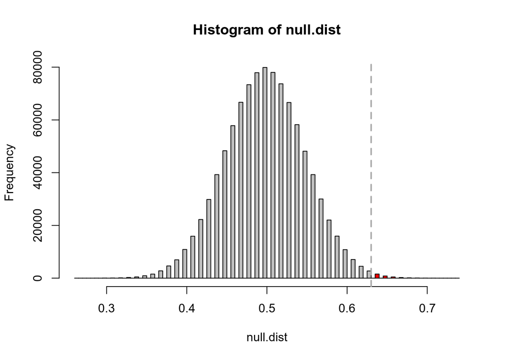

```r
# creating our own p-value:
# generate a random number of "heads" for 100 coin flips, 10000 times:
null.dist <- rbinom(1000000, 100, 0.5) / 100
{h <- hist(null.dist, breaks = 100, plot = FALSE)
  clr <- ifelse(h$breaks <= 0.63, "grey", "red")[-length(h$breaks)]
  plot(h, col = clr)
abline(v = 0.63, col = "darkgrey", lwd = 2, lty = 2)}
```

```r
# should have a mean of about 0.5
mean(null.dist)
```

```
## [1] 0.4999821
```

```r
# how many are as extreme or more extreme than a proportion of 0.63?
sum(null.dist >= 0.63) / length(null.dist) # should be on the order of 10^-3
```

```
## [1] 0.00597
```

```r
# what if we use the built-in r function to sample from a true normal distribution?
2 * (1 - pbinom(63, 100, 0.5))
```

```
## [1] 0.006637121
```

- Apparently, this is an unfair lizard.
- This is statistically sound, but biologically uninteresting. Any two species (or populations, or genera, or individuals) will stop looking identical if you measure them enough.
- P-values are imperfect reflections of likelihood. A small p-value can result from a very large effect ($\mu_{H} - \mu_{D}$ is big) or a large sample size (n is big).

## 2.3: Maximum likelihood

- Instead of binary hypotheses (reject the null/fail to reject the null), likelihoods are a more nuanced approach.
- Likelihood = **the probability of observing the collected data, given a model and a set of parameter values**.
- General expression of likelihood:

$$L(H|D) = Pr(D|H)$$

- In English, this reads as “the likelihood of the hypothesis given the data is equal to the probability of the data given the hypothesis”.
- In *plain* English, this means that likelihood is the probability of seeing our observed data given a model and a set of parameters.
- So the best model is defined as the one with the highest probability of generating the observed data.
- In practice, we calculate likelihood for binomial theorem as:

$$L(H|D) = Pr(D|p) = \begin{pmatrix} n \\ H \end{pmatrix} p_{H}^{n}(1-p_{H})^{n-H}$$
* Where ($\begin{pmatrix} n \\ H \end{pmatrix} = \frac{n!}{(n-H)!H!}$)

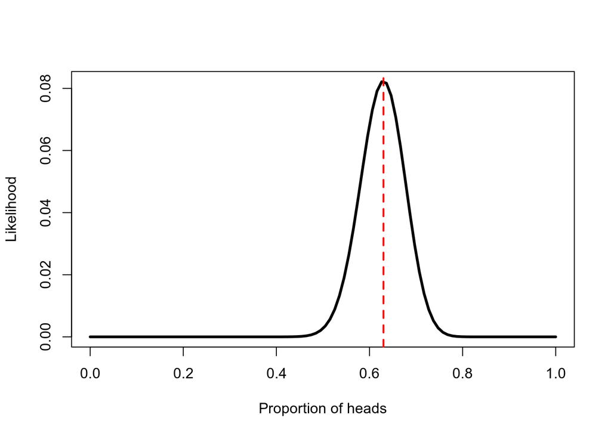

```r
n <- 100
H <- 63
p_h <- seq(0, 1, length.out = 100)

lklhd <- function(p, n, H) {
  fac <- factorial(n) / (factorial(n - H) * factorial(H))
  l <- fac * p^63 * (1 - p)^37
  return(l)
}

p <- sapply(p_h, function(i) lklhd(i, n, H))

{plot(p_h, p, type = 'l', lwd = 3, xlab = "Proportion of heads", ylab = "Likelihood")
  abline(v = 0.63, col = "red", lty = 2, lwd = 2)}
```

- Ok. That worked. What a relief.
- This is brute force: we have an expression, and we try a bunch of parameters, and then we pick the best set. This is OK if you have no idea what’s going on, but there is usually a faster way that involves understanding math a little bit.
- Luke Harmon is gonna explain that later I guess.
- You can also do this with differentiation to find the maximum. First take the log to make things additive:

$$ln L = \ln {\begin{pmatrix} n \\ H \end{pmatrix}} + H*\ln{p_{H}} + (n-H)*\ln{(1-p_{H})}$$

- Peak likelihood will be when the derivative of likelihood is equal to 0:

$$\frac{d(\ln{L})}{dp_H} = H / p_H - \frac{n-H}{1-p_H} = 0$$

- If you go through the whole rigamarole of solving for $p_H$ above, you end up with $p_H = H / n$.
- So $p_H = 63/100 = 0.63$.
- Which is where the red line is. So that’s good.

### Limitations: bias and precision

- **Precision**: a measure of how different estimates are for the same measurement.
- **Bias**: a measure of how close estimates are to the true value.
- In general, estimates are less biased with larger sample sizes.

## 2.3b: Likelihood ratio test

- A likelihood ratio test compares two models where one is a special case of the other.
- For example: probability of heads = 0.5 is a special case of probability of heads is between 0 and 1.
- Test statistic is:

$$\Delta = 2 * \ln{\frac{L_1}{L_2}} = 2 * (\ln{L_1} - \ln{L_2})$$

- Basically 2x the difference in log likelihoods.
- Then you ask if $\Delta$ is bigger than you would expect under the null hypothesis, taken from a $\chi^{2}$ distribution with df = difference in number of parameters.

```r
L1 <- log(lklhd(0.5, 100, 63)); L1
```

```
## [1] -5.915271
```

```r
L2 <- log(lklhd(0.63, 100, 63)); L2
```

```
## [1] -2.496121
```

```r
ratio <- 2*(L2 - L1); ratio
```

```
## [1] 6.8383
```

```r
1 - pchisq(ratio, df = 1)
```

```
## [1] 0.008922371
```

### Limitations

- Requires models to be nested.
- Makes it difficult to compare multiple models systematically (you can do a sort of round robin approach, but the results might depend on the order of the tests).

## 2.3c: AIC

- Tries to balance simplicity with likelihood when evaluating a model.

$$AIC = 2k - 2\ln{L}$$

- Where *k* is the number of parameters. AIC will decrease with fewer parameters or a higher likelihood.
- When choosing a model, one way to choose the “best” model is to choose the one with the lowest AIC.
- This has the advantage of not requiring models to be nested.
- The 2x weighting is based on information theory, not rule of thumb.
- Still, only valid when you have many more observations than parameters ($n/k > 40$).
- With sample size correction:

$$AIC_c = AIC + \frac{2k(k+1)}{n-k-1}$$

```r
# AIC for no estimated parameters:
AIC_1 <- 2*0 - 2*L1; AIC_1
```

```
## [1] 11.83054
```

```r
AIC_2 <- 2*1 - 2*L2; AIC_2
```

```
## [1] 6.992243
```

```r
# size-corrected:
AIC_1 + 2*0*(0+1) / (100 - 0 - 1)
```

```
## [1] 11.83054
```

```r
AIC_2 + 2*1*(1+1) / (100 - 1 - 1)
```

```
## [1] 7.033059
```

```r
AIC_1 - AIC_2
```

```
## [1] 4.8383
```

- Uh it’s big. Whatever. You get it.
- You can also use AIC weights and weight the parameter estimates from different values according to their weights. Then you combine the weighted estimates across models, proportional to the support for those models.

## 2.4: Bayesian statistics

$$Pr(H|D) = \frac{Pr(D|H)*Pr(H)}{Pr(D)}$$

- The probability of the hypothesis given the data is equal to the probability of the data given the hypothesis, times the probability of the hypothesis, divided by the probability of the data.
- Requires prior knowledge about hypothesis probability ($Pr(H)$). Scientists try to use priors that don’t affect the posterior probability very much.
- What about $Pr(D)$?
  - This is the probability of obtaining the data, integrated over the prior distributions of the parameters:

  $$Pr(D) = \int Pr(H|D) Pr(H) dH$$
- It usually doesn’t matter, since it’s held constant over all the models you’re testing.
- For model 1, there are no parameters, so $Pr(H) = 1$, $Pr(D|H) = P(D)$, so $Pr(H|D) = 1$.
- For model 2, set a uniform prior between 0 and 1, writtenas “our prior for $p_h$ is U(0,1)”.
- This turns into some ugly expression which simplify to a beta distribution wiki:

$$Pr(H|D) = \frac{(N+1)!}{H!(N-H)!}*p_H^{H}(1-p_{H})^{N-H}$$

- Apparently this is “nicer”. Ok.

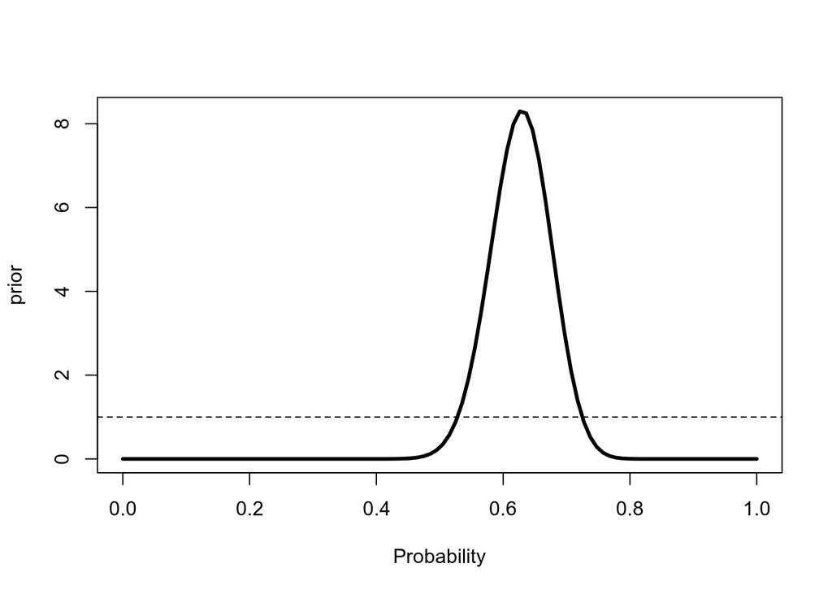

```r
# compare posterior and prior probability distributions:

prior <- 1
bayesian <- function(n, H, p) {
  b <- factorial(n + 1) / (factorial(H) * factorial(n - H)) * p^H * (1-p)^(n-H)
  return(b)
}

b <- sapply(seq(0, 1, length.out = 100), function(i) bayesian(100, 63, i))

{plot(seq(0, 1, length.out = 100), b, type = 'l',
     lwd = 3,
     ylab = "prior",
     xlab = "Probability")
  abline(h = prior, lty = 2)}
```

## 2.4b: Bayesian Markov-chain Monte Carlo (MCMC)

- This sounds fancy but basically it means you just apply the same process to an estimate over and over until it stops changing.
- So like, you multiply a matrix over and over until it reaches a steady state. Etc. It’s very ham-handed, which is why people like me like it.
- In this particular case, we’re walking around parameter space in sequential steps until we get stuck somewhere nice, which will be the Bayesian posterior distribution.
- You keep updating the parameter estimate until it stops changing.
- The set of steps to land in the valley of Bayesian posterior probabilities is roughly this:
  1. Start with some reasonable parameter value.
  - Sample a starting parameter value ($p_0$) from the prior distribution.
  2. For every iteration, decide on a new parameter value, $p'$, using the proposal desnity $Q(p'|p)$.
  3. Calculate three ratios:
  1. *Prior odds ratio*: probability drawing the parameter values $p$ and $p'$ from the prior:
     $$R_{prior} = \frac{P(p')}{P(p)}$$
     - I’m guessing that if it’s > 1, you swap out $p$ for $p'$, because your new parameter value is better (higher probability) than the previous one.
  2. *Proposal density ratio*: Ratio of the probability of proposals going from $p$ to $p'$ vs. the probability of proposals going from $p'$ to $p$. - These are constructed to be symmetrical.

  $$R_{proposal} = \frac{Q(p'|p)}{Q(p|p')}$$
  3. *Likelihood ratio*: Ratio of probabilities of the data, given the two different paramter values.

  $$R_{likelihood} = \frac{L(p'|D)}{L(p|D)} = \frac{P(D|p')}{P(D|p)}$$
  4. Multiply the above three values (prior odds ratio, proposal density ratio, and likelihood ratio):

  $$R_{accept} = R_{prior} * R_{proposal} * R_{likelihood}$$
  5. Accept or reject. How? Draw a random number from [0, 1]; if $x < R_{accept}$, accept the new $p$ ($p_i = p'$), and otherwise reject it and retain your current guess ($p$).
  6. Repeat steps 2-5 until you converge on a value within a tolerable noise threshold.
- As you might guess, $p$ jumps around *a lot* at first, because new guesses won’t always be better, and $x$ introduces a semi-random element for the acceptance/rejection threshold. This is called the **burn-in** period.
- After you’re past the burn-in period, each step in the chain is a sample from the posterior distribution.
- So there’s not going to be a single, perfect parameter on which you converge; you end up oscillating within a range of likely values. You can summarize this in plenty of ways – histograms, confidence intervals, means and standard distributions, etc.

### Ok, but to bring it back to the lizard flips…

- Start with a prior distribution of $U(0, 1)$ for $p$.
- To choose new proposal values ($p'$), we’ll add a small number ($\epsilon \leq 0.01$) to $p$, so $Q(p'|p) = U(p-\epsilon, p+\epsilon)$.

```r
# pick a starting parameter value and epsilon
# p <- runif(1); we'll use 0.6 because it's what the book does
p <- 0.6
e <- 0.01

# propose a new value
p2 <- runif(1, p-e, p+e); p2
```

```
## [1] 0.5903394
```

- Calculate the three ratios above:
- The prior odds ratio ($R_{prior}$) will *always be 1* because the prior probability distribution is $U(0, 1)$. You can’t have a probability outside of this range (i.e. something less than 0% or more than 100% chance of being correct). Since both $p$ and $p'$ will always have a probability distribution of 1, our prior odds ratio will always be 1:

$$R_{prior} = \frac{P(p')}{P(p)} = \frac{1}{1} = 1$$

- RIVETING
- Ok. Our proposal distribution will also be symmetrical for the same reasons ($Q(p'|p) = Q(p|p')$), so $R_{proposal} = 1$).
- We only have to calculate the likelihood ratio!

```r
# let's redifine this guy as a reminder
likelihood <- function(p, n, H) {
  fac <- factorial(n) / (factorial(n - H) * factorial(H))
  l <- fac * p^63 * (1 - p)^37
  return(l)
}

# calculate likelihoods
L1 <- likelihood(p, 100, 63); L1
```

```
## [1] 0.06819905
```

```r
L2 <- likelihood(p2, 100, 63); L2
```

```
## [1] 0.05931123
```

```r
# get likelihood ratio
L_ratio <- L2 / L1; L_ratio
```

```
## [1] 0.8696783
```

```r
# acceptance ratio
# in this case, just equal to L_ratio
R_accept <- 1 * 1 * L_ratio; R_accept
```

```
## [1] 0.8696783
```

```r
# choose a random threshold
x <- runif(1)

# if x is lower than the acceptance ratio, keep current p
if (x <= R_accept) {

  p <- p2

}
```

- $R_{accept}$ will increase as $p'$ becomes more likely with respect to $p$. If $p'$ has a likelihood very similar to that of $p$, very few values of $x$ will be greater than $R_{accept}$; if $P(D|p') > P(D|p)$, then $R_{accept} > 1$, and $x$ will always be lower.
- So you’ll never reject a $p'$ that gives you better results, and you’ll only rarely accept one that’s considerably worse.
- Maybe this seems inefficient – why introduce this $x$ business at all? Isn’t it more efficient to just say if $R_{accept} \geq 1$, keep $p'$?
- The idea here is not to get *stuck* anywhere in parameter space. If you used a hard threshold, you might get to a local maxima, but if you’re not allowed to occasionally go downhill or sideways, you’ll never discover the rest of the landscape.
- You could turn this into a metaphor about facing personal challenges if you want, but I wouldn’t think about it too hard.
- Anyways, keep doing this for a while. This is so simple we can actually do it in R, which is a sentence I think counts as a self-own:

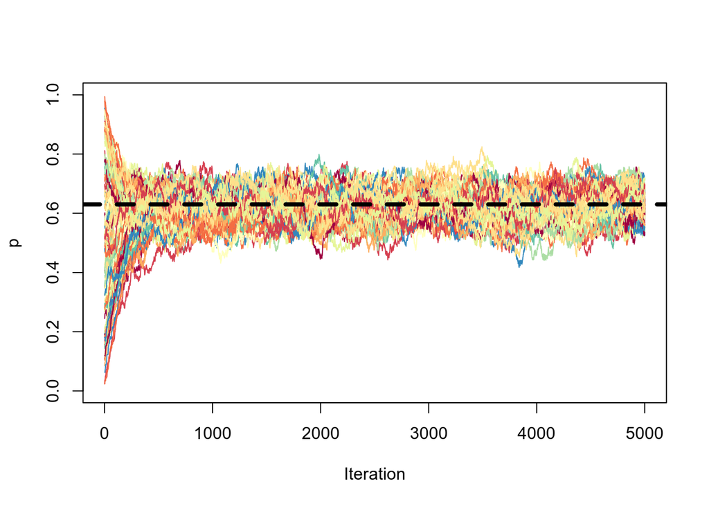

```r
likelihood <- function(p, n, H) {
  fac <- factorial(n) / (factorial(n - H) * factorial(H))
  l <- fac * p^H * (1 - p)^(n - H)
  return(l)
}

MCMC <- function(n, H, p = "rand",
                 U = c(0, 1),
                 e = 0.01,
                 iter = 5000) {

  # get starting parameter if not specified
  if (p == "rand") {
    p <- runif(1, min = U[1], max = U[2])
  }

  # store values in a vector
  p_vec <- p

  for (i in 1:iter) {
    # propose a new value
    p2 <- runif(1, min = p-e, max = p+e)

    # get their likelihoods
    L1 <- likelihood(p, n, H)
    L2 <- likelihood(p2, n, H)

    # likelihood ratio
    L_ratio <- L2 / L1

    # generate random threshold
    x <- runif(1)

    if (x <= L_ratio) {
      p <- p2
    }

    p_vec <- c(p_vec, p)

  }

  return(p_vec)

}

# define color vector
colors <- RColorBrewer::brewer.pal(11, "Spectral")

# plot 101 runs
plot(MCMC(n = 100, H = 63),
     type = 'l', col = colors[runif(1, 1, length(colors))],
     ylim = c(0, 1),
     ylab = "p", xlab = "Iteration")
for (i in 1:100) {
  points(MCMC(n = 100, H = 63),
         type = 'l', col = colors[runif(1, 1, length(colors))])
}
abline(h = 0.63, lty = 2, lwd = 4, col = "black")
```

- Hopefully, what you should see is a bunch of squiggly multicolored lines starting anywhere between 0 and 1 and eventually wiggling towards 0.63 and kind of plateauing.
- We can also plot as a histogram:

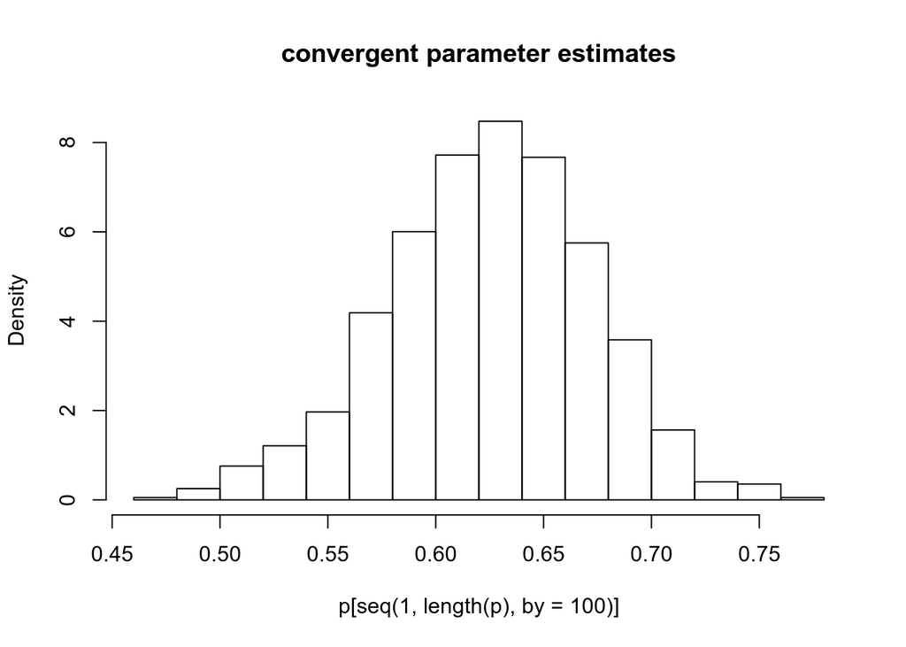

```r
p <- MCMC(100, 63, iter = 100000)

# chop off the "burn-in" segment
p <- p[-c(1:1000)]

# let's overlay our old bayesian friend, the Metropolis-Hastings algorithm
bayesian <- function(n, H, p) {
  b <- factorial(n + 1) / (factorial(H) * factorial(n - H)) * p^H * (1-p)^(n-H)
  return(b)
}

b <- sapply(seq(0, 1, length.out = 100), function(i) bayesian(100, 63, i))

# take every 100th value to avoid autocorrelation
hist(p[seq(1, length(p), by = 100)],
     probability = T,
     main = "convergent parameter estimates")
```

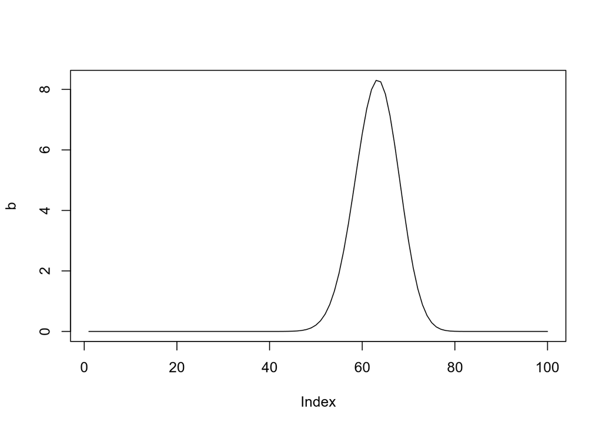

```r
plot(b, type = 'l')
```

## 2.4c: Bayes factors

- Ok, so now we know how to use a set of data and a prior assumption about the model to calculate a posterior probability distribution.
- But how do you actually select a model using Bayesian statistics?
- We went over AIC earlier as a general concept – balancing fewer parameters with ability to explain the data.
- Simplest method in a Bayesian framework: calculate a bunch of posterior probabilities using different models, then compare across models.
- You can do this by calculating **Bayes factors**, which are the *ratios of marginal likelihoods of two competing models*:

$$B_{12} = \frac{Pr(D|H_1)}{Pr(D|H_2)}$$

# Chapter 3: Introduction to Brownian Motion

## 3.2: Properties of Brownian Motion

- Brownian motion is the workhorse “random walk” model of evolution. It’s an implementation of the assumption that a trait will change randomly, both in direction and distance, over any time interval.
- The core of this assumption is that you have an output (trait) whose motion (evolution) is determined by a bunch of small, more or less random forces, rather than a dominate, directional pressure.
- But apparently it’s not equivalent to genetic drift?
- Evolutionary model using Brownian motion usually models the mean character value, $\bar z$, of a population. At a given time, the mean trait value will be $\bar z(t)$.
- You only need two parameters for a BMM: starting trait value, $\bar z(0)$, and the evolutionary rate parameter, $\sigma^2$, which determines how fast traits walk.
- If a trait is changing under a BMM, its values over an interval of time are drawn from a normal distribution with mean 0 and variance proportional to evolutionary rate x time (variance = $\sigma^2t$), making them easy to simulate.
- So the more time has passed, the wider the variation in the trait value.
- If you simulate BM enough times, then sample the distribution of the trait at given timepoints, you’ll see a normal distribution centered around the starting value of the trait that gets wider as more time passes.

### 3 main properties of Brownian Motion

1. $E[\bar z(t)] = \bar z(0)$
2. Each successive interval of the “walk” is independent
3. $\bar z(t) \sim N(\bar z(0),\sigma^2t)$
- Ok he just listed these out but I don’t know what the hell these mean.
1. $E[\bar z(t)] = \bar z(0)$: The *expected value of the character* (E) at time $t$ is equal to the *starting value of the character*. This obviously won’t usually be the case – the trait value will wander as a function of the normal distribution – but we don’t expect it to drift toward any other value in particular. So on average, it will end up right where it started.